# Units Player UI

In the last lesson, we coded player unit selection and deselection.

We need to cover one last part to complete the user feedback: the selection UI.

We’ll add a list of icons in the top-left corner of the screen representing the player’s units.

Clicking an icon in the UI will select the corresponding unit.

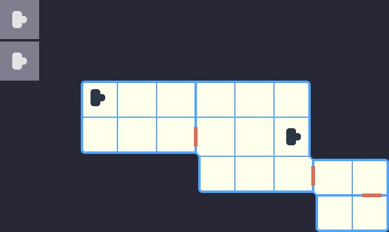

We’ll generate the UI elements at run-time dynamically, based on the number of the units we place in the player ship.

## Main game scene

We want to separate the interface’s nodes from the rest of the game world. That split is common in games: it allows us to have the UI draw over the game world, in a separate layer.

We’ll now create our main game scene with the following node structure:

- A

[figure not shown]

  `Node2D` at the root named *TacticalSpaceCombat*.
  - An instance of our *ShipPlayer* scene.
  - A

[figure not shown]

    `Control` node named *UI*.
    - A

[figure not shown]

      `VBoxContainer` node named *Units*.

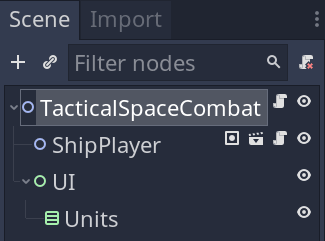

The *Units* node will list and align the units’ UI vertically for us.

You can save the scene file at `res://TacticalSpaceCombat.tscn`.

## UI unit scene

We first prepare the UI scene we’ll use at run-time to populate the *TacticalSpaceCombat -> Units* node.

Create a new empty scene with the following tree:

- A

[figure not shown]

  `ColorRect` node named *UIUnit*. It’ll be our UI’s background.
  - A

[figure not shown]

    `NinePatchRect` node named *Icon*. That’s our unit’s representation.
  - Another

[figure not shown]

    `NinePatchRect` node named *Feedback*. We’ll use it to outline selected units in the interface.

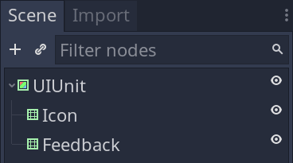

Make sure to save the scene at `res://TacticalSpaceCombat/UI/UIUnit.tscn`.

To make it look like in the example screenshot from the introduction, we have to adjust some settings in the *Inspector*. Select the *UIUnit* node and set the properties like so:

- *Color*: `#7e7e8f`. It’s a light gray.
- *Rect -> Min Size* to `Vector2(64, 64)`. This will also update *Size*.

Next, update the *Icon* node’s properties like so:

- The *Texture* property is, as usual, set to the `res://TacticalSpaceCombat/Assets/Assets.svg` atlas, where we have most of the necessary game visuals.
- For the region rect, it’s the same as the units’ sprite: `Rect2(64, 384, 24, 32)`.
- Set the *Rect -> Size* to `Vector2(24, 32)` to match the texture region.

Then, use the *Layout -> Center* option in the toolbar to center the unit inside its parent

[figure not shown]

`ColorRect` node.

[figure not shown]

This will position the icon in the middle of the *Unit* root node.

*Note* that we’re using a

[figure not shown]

`NinePatchRect` node for the icon, even though it doesn’t have a border, because it’s a UI node that gives us the ability to pick a region from the texture. Another way get the same result is to use a `TetureRect` node with an

[figure not shown]

`AtlasTexture` resource.

For the *Feedback* node, we need to do a little more work:

- The *Texture* should still be `res://TacticalSpaceCombat/Assets/Assets.svg`.
- Set its *Region Rect* to `Rect2(0, 416, 32, 32)`.
- Set all four of its *Patch Margin* to `8` pixels. This property defines the size of the nine-patch’s borders on the texture.

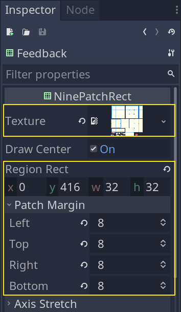

Use *Layout -> Full Rect* to have the *Feedback* node expand to fill its parent.

You should see a border surrounding the background.

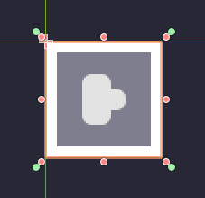

Make the *Feedback* node invisible next.

We’ll use this *Feedback* rectangle to show selected units, so it should be hidden by default.

We also use a very similar setup in the next lesson when expanding the *Room* node. To make our lives easier, save the *Feedback* node as a separate scene by selecting *Save Branch as Scene* from the right click menu.

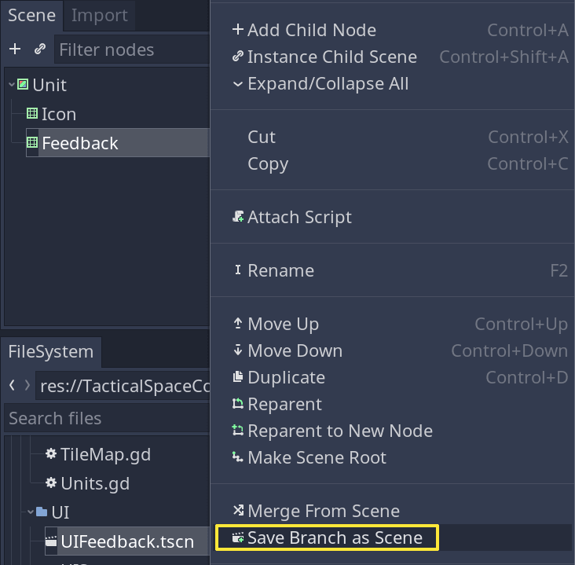

Save the scene at `res://TacticalSpaceCombat/UI/UIFeedback.tscn`.

## Run-time player unit UI elements

Now that we finished setting up the UI unit scene, we’re ready to add it to our game in real-time.

Before we code the UI creation, we need to store a reference to the *ShipTemplate*’s *Units* node, our container for units walking around the ship.

Open `ShipTemplate.gd` and add the following line:

```
onready var units: Node2D = $Units
```

Then, head back to the main game scene, `TacticalSpaceCombat.tscn`, and attach a script to the *TacticalSpaceCombat* parent node.

We’ll have it look at the units and generate the interface accordingly, as it’s the common parent to both the UI and the ships in our game.

It should have the following content:

```
extends Node2D

# We preload the `UIUnit` scene to instantiate it from the code.
const UIUnit = preload("TacticalSpaceCombat/UI/UIUnit.tscn")

# As the common parent to the ship and UI, we allow this node to access both
# and work as the link to set up the two.
onready var ship_player: Node2D = $ShipPlayer
onready var ui_units: VBoxContainer = $UI/Units


func _ready() -> void:
    _ready_units()


## Creates the player UI to select units.
func _ready_units() -> void:
    for unit in ship_player.units.get_children():
        var ui_unit: ColorRect = UIUnit.instance()
        ui_units.add_child(ui_unit)
```

I’m already splitting the ready function into smaller `_ready_*()` functions. This helps us keep everything organized and manageable as we move along with the course.

I moved *ShipPlayer* off the origin, so it doesn’t overlap with the UI elements.

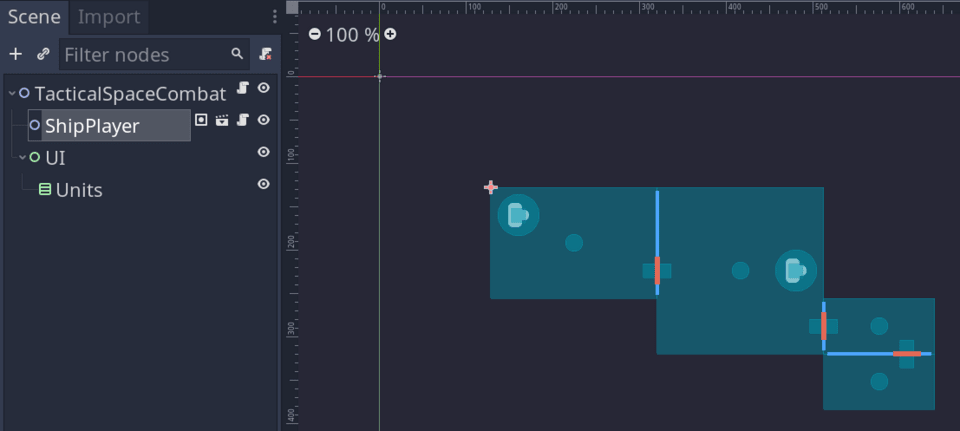

If you run (`F5`) the game now, you can set the `TacticalSpaceCombat.tscn` as the main scene. You should see the interface:

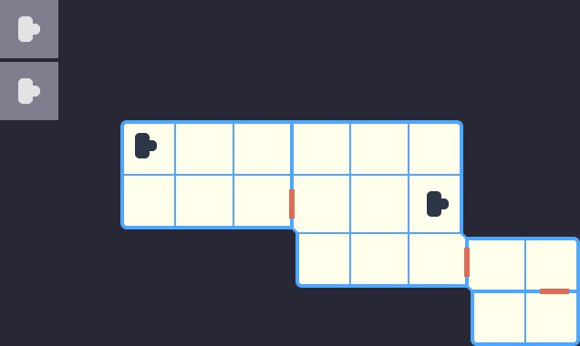

The UI should list as many *UIUnit* instances as there are units in our *ShipPlayer*.

## Player unit UI interaction

Up to this point, we worked on the cosmetic part of the game. The player can’t interact with the UI elements yet. Let’s fix this now.

Instead of handling player input on the *UIUnit* instances, we’ll handle them all from `UnitPlayer.gd`.

To do so, we’ll store a reference to the UI on the *UnitPlayer*, creating a strong dependency.

This isn’t all bad, though, because this kind of user interface is generally highly specialized for a given entity or mechanic.

We’ll use a similar approach in most places where we have to handle UI-game world interaction because it’s much simpler than connecting signals from game entities to the UI and back. It can limit spaghetti code by keeping it all in one place.

It works especially well for simple widgets like our unit selection. For really complex user interfaces and games, you may prefer to separate them entirely from the game world’s code.

You’ll see more examples of this in the lessons to come.

Now open `UnitPlayer.gd` and add the following code:

```
## Reference to the UI player feedback element. We need to set its state when units
## get selected/deselected.
var _ui_unit_feedback: NinePatchRect

func setup(ui_unit: ColorRect) -> void:
    _ui_unit_feedback = ui_unit.get_node("Feedback")

    # We get the icon and adjust its color from code so that it always stays in
    # sync with `COLORS.default`.
    # We don't add a script to UIUnit, which is why we're getting the Icon node
    # here.
    ui_unit.get_node("Icon").modulate = COLORS.default

    # Instead of overriding `_gui_input()` in the _UIUnit_ UI node, we prefer to
    # use the `gui_input` signal to handle all player interaction right here.
    #
    # This can simplify UI - game entities interactions by a lot.
    ui_unit.connect("gui_input", self, "_on_UIUnit_gui_input")


func _on_UIUnit_gui_input(event: InputEvent) -> void:
    # Remember that we use used `_input()` instead of `_unhandled_input()`
    # in `Units.gd`. This function is why. With `_unhandled_input()`, we would
    # ignore the UI clicks in `Units.gd`. We'd keep on selecting new units
    # without deselecting previous ones.
    if event.is_action_pressed("left_click"):
        self.is_selected = true


func set_is_selected(value: bool) -> void:
    # ...
    # When changing the unit's selection state, we update the ui widget to show the
    # outline.
    # We need this `null` check here, otherwise, Godot will complain at the
    # start of the game, as setter functions run once before _ready(), when
    # the nodes' constructors (_init()) run.
    if _ui_unit_feedback != null:
        _ui_unit_feedback.visible = is_selected
```

The `setup()` function should be self-explanatory. We store a reference to the relevant UI nodes for easy access and set the default icon color to `COLORS.default`. `Colors.default` is a property defined in the `Unit` class in the previous lesson.

We have to make one last modification to call the `setup()` function from the main scene. Open `TacticalSpaceCombat.gd` and add the following call to set up the units:

```
func _ready_units() -> void:
    # ...
        # ui_units.add_child(ui_unit)
        unit.setup(ui_unit)
```

If you now run the game, you should be able to select a unit by clicking its portrait.

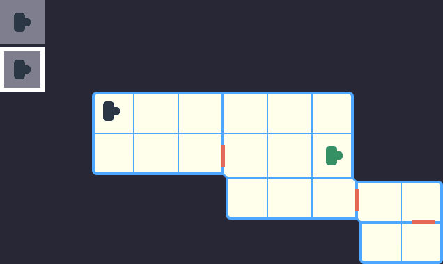

When we click on the UI elements, they will select the player units while visually showing the *Feedback* rectangle.

To keep it simple, we select player units on `LMB` click in the UI elements without any other operations. To deselect the units, press anywhere else in the game space apart from the units themselves.

The UI elements will update whenever the player selects a unit from the game space as well.

## Conclusion

With this, we conclude our implementation for the player UI units.

We covered how to:

1. Populate UI elements at run-time depending on the nodes in our game scene tree.
2. How to work with

[figure not shown]

   `Control` nodes.
3. A trick of using the `gui_input` signal instead of overwriting the `gui_input()` virtual function to have an easier time handling player-UI interactions.

In the next lesson, we’ll take a short detour to take care of room mouse hovering feedback for the player. After which, we return to our mission of coding unit movement around the ship.

## Code reference

```
extends Node2D

const UIUnit = preload("TacticalSpaceCombat/UI/UIUnit.tscn")

onready var ship_player: Node2D = $ShipPlayer
onready var ui_units: VBoxContainer = $UI/Units


func _ready() -> void:
    _ready_units()


func _ready_units() -> void:
    for unit in ship_player.units.get_children():
        var ui_unit: ColorRect = UIUnit.instance()
        ui_units.add_child(ui_unit)
        unit.setup(ui_unit)
```

`res://TacticalSpaceCombat/Ship/Units/UnitPlayer.gd`:

```
extends Unit

var is_selected: bool setget set_is_selected

var _ui_unit_feedback: NinePatchRect

onready var area_select: Area2D = $PathFollow2D/AreaSelect


func setup(ui_unit: ColorRect) -> void:
    _ui_unit_feedback = ui_unit.get_node("Feedback")
    ui_unit.get_node("Icon").modulate = COLORS.default
    ui_unit.connect("gui_input", self, "_on_UIUnit_gui_input")


func _ready() -> void:
    self.is_selected = false


func _on_UIUnit_gui_input(event: InputEvent) -> void:
    if event.is_action_pressed("left_click"):
        self.is_selected = true


func set_is_selected(value: bool) -> void:
    var group := "selected-unit"

    is_selected = value
    if is_selected:
        area_unit.modulate = COLORS.selected
        add_to_group(group)
    else:
        area_unit.modulate = COLORS.default
        if is_in_group(group):
            remove_from_group(group)

    if _ui_unit_feedback != null:
        _ui_unit_feedback.visible = is_selected
```